# METODOLOGÍA DE IDENTIFICACIÓN DE REDES DE ESTRUCTURACIÓN DE LD

—–WIP—–

Enrique Cuervo Guzmán

2022-03-08

```r
library(knitr)   # @xie2014

opts_chunk$set(echo=FALSE, warning = FALSE, message = FALSE)
```

# PLANTEAMIENTO

Suresh, Thammi Reddy, and Sweta (2016) plantean un esquema para la detección eficiente de cuentas, operaciones y montos involucrados en operaciones de estructuración de LD utilizando grafos (redes). Es relevante observar que, tratándose del diseño de criterios o escenarios de alertamiento para la identificación de operaciones sospechosas, lo más frecuente es encontrarse con metodologías enfocadas principalmente en las fases del LD conocidas como la *colocación* o *integración*, dado que son las etapas del LD en las que resulta un poco más inmediato identificar irregularidades. Sin embargo, con rara frecuencia encontramos criterios de alertamiento dirigidos a la fase de *estructuración* del LD, motivo por el cual el trabajo de Suresh, Thammi Reddy, and Sweta (2016) resulta relevante.

Michel and Ávila Torres (2020), por ejemplo, definen a la etapa de estructuración como “la realización de múltiples transacciones financieras sucesivas, con la intención de borrar el rastro de los fondos obtenidos ilícitamente”. Es claro que la identificación de la estructuración tiende a ser compleja. Como Suresh, Thammi Reddy, and Sweta (2016) señalan, dado que la estructuración puede ser una relación “de uno a muchos”, la dificultad se origina en trazar todo la cadena de transacciones.

Para ello, Suresh, Thammi Reddy, and Sweta (2016) proponen aplicar un criterio basado en Teoría de Gráficas con el objetivo de poder detectar dependencias complejas entre transacciones. En términos generales, proponen aplicar un algoritmo de “ruta más larga” en una gráfica dirigida acíclica, para identificar la “ruta” seguida por un monto transferido; por otra parte, utilizando medidas de grado de entrada y grado de salida de cada nodo, se busca identificar nodos (esto es, cuentas) de tipo “agente” o “integrador”.

Un problema del artículo es que no señala cómo identificar a las redes sospechosas. Es decir, establecer el criterio de inusualidad para la red (a lo mejor y sí lo plantean, por eso volver a leer).

Finalmente, otro problema o posible mejora, es que lo basan en la frecuencia de las operaciones, pero se pude hacer o combinar con el monto.

Otras consideraciones:

- Para que funcione no se deben considerar depósitos o retiros, sino solamente los recursos ya ingresados a la entidad, pues uno supone que el nodo integrador en algún momento retira todos los recursos.
- No se plantean los criterios para establecer los umbrales.
- Se pueden agregar otros criterios de inusualidad, como el grado de la red, o la importancia de algunos nodos dentro de la red.

# EJEMPLO

## SIMULACIÓN DE OPERACIONES

Una entidad financiera que tiene $N_1$ cuentas. Cada una de esas cuentas realiza un número de operaciones $O$ durante el periodo de análisis. $O$, a su vez, está compuesto por $O_1$ operaciones con otras cuentas abiertas en la entidad y $O_2$ operaciones con cuentas fuera de la entidad (de las cuales se observa un número total $N_2$, pero con las cuales cada cliente solamente opera con una muestra de tamaño $N_3$). Cada operación tiene asignado un monto $M$ y un tipo de operación $T$, que determina la dirección de la operación desde la perspectiva de la cuenta (entrada o salida de recursos).

$$N_1 \sim Poisson(\lambda_1)$$

```
## [1] 1529
```

$$N_2 \sim Poisson(\lambda_2)$$

```
## [1] 4899
```

$$N_3 \sim Poisson(\lambda_4)$$

$$N_4 \sim Poisson(\lambda_5)$$

$$O \sim Poisson(\lambda_3)$$

```
##    Min. 1st Qu.  Median    Mean 3rd Qu.    Max.
##   30.00   47.00   52.00   52.07   57.00   82.00
```

```
## [1] 79618
```

$$O_i = r_iO_i + (1 - r_i)O_i = O_{i1} + O_{i2};r_i \sim U(0,1)$$

```
##      Min.   1st Qu.    Median      Mean   3rd Qu.      Max.
## 0.0009328 0.2408680 0.4959577 0.4931944 0.7436660 0.9999023
```

$$T \sim Bernoulli(p)$$

```
## TIPO.TR
##    -1     1
## 27842 51776
```

$$M \sim Gamma(\alpha, \beta)$$

```
##    Min. 1st Qu.  Median    Mean 3rd Qu.    Max.
##   14420   14918   15000   15001   15083   15541
```

# GRÁFICA

La siguienta tabla muestra los datos agregados de un vértices seleccionado aleatoriamente.

| CUENTA | CONTRAPARTE | MONTO |
| --- | --- | --- |
| 836 | 1164 | 15035.8816452729 |
| 836 | 1496 | 14928.8638095563 |
| 836 | 384 | 14814.1538679335 |
| 836 | 597 | 15009.4366635769 |
| 130 | 836 | 120233.311835341 |
| 132 | 836 | 15013.9081904625 |
| 487 | 836 | 14818.3904933056 |
| 709 | 836 | 15051.3515314734 |
| 836 | E1126 | 104794.310326632 |
| 836 | E1138 | 15036.3252032823 |

[output cut: 12 more lines]

Abajo se presenta la gráfica (no dirigida) de los datos del vértice seleccionado aleatoriamente. El nodo en rojo representa al vértice seleccionado, en amarillo se muestran sus contrapartes “internas” y en verde las “externas”.

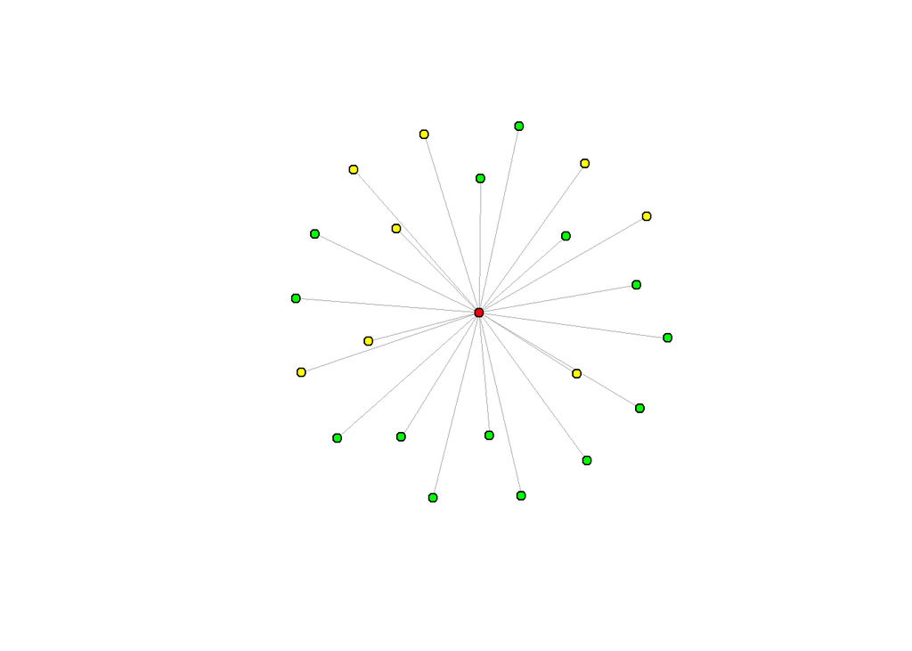

Ahora haremos crecer la red a un grupo mayor de vértices (nuevamente, seleccionados al azar, pero manteniendo al previamente seleccionado):

| CUENTA | CONTRAPARTE | MONTO |
| --- | --- | --- |
| 836 | 1164 | 15035.8816452729 |
| 836 | 1496 | 14928.8638095563 |
| 836 | 384 | 14814.1538679335 |
| 836 | 597 | 15009.4366635769 |
| 130 | 836 | 120233.311835341 |
| 132 | 836 | 15013.9081904625 |
| 487 | 836 | 14818.3904933056 |
| 709 | 836 | 15051.3515314734 |
| 836 | E1126 | 104794.310326632 |
| 836 | E1138 | 15036.3252032823 |

[output cut: 12 more lines]

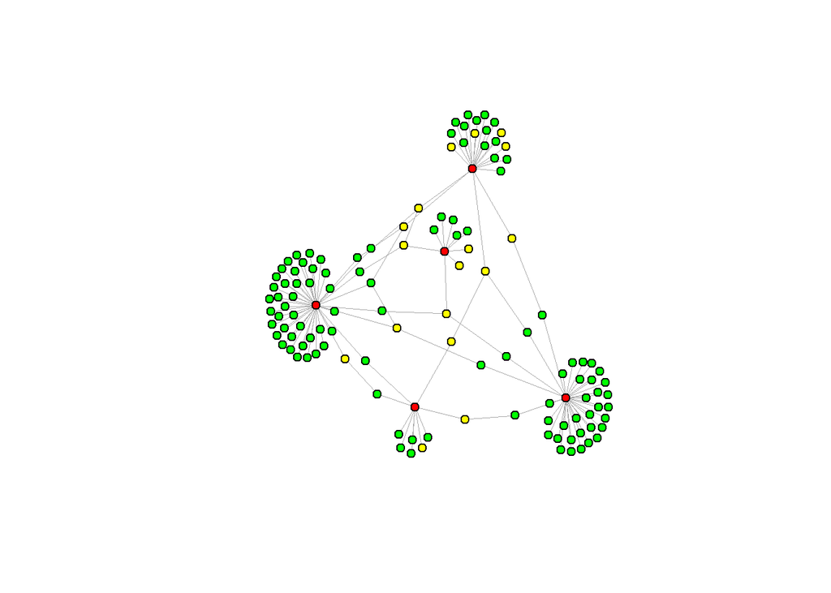

Hacemos ahora la gráfica dirigida:

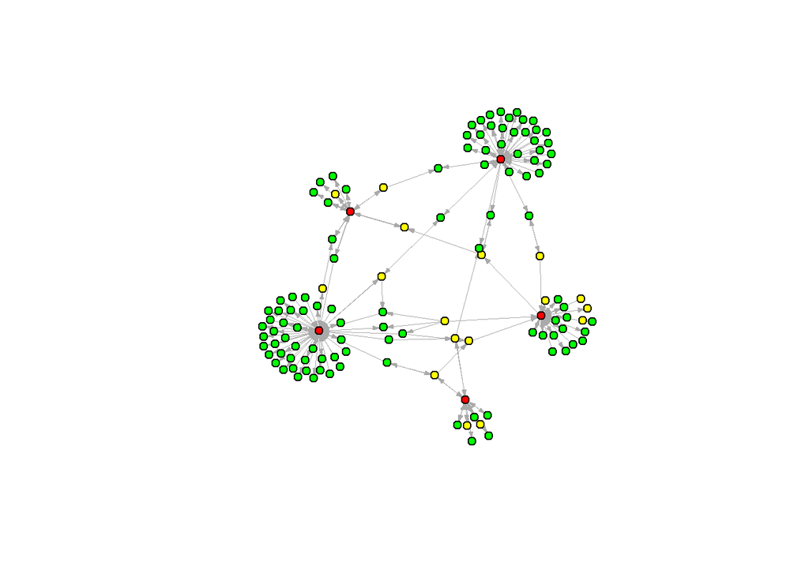

# PASO 1: FUNCIÓN HASH Y TABLA DE CONTINGENCIA

```
##
##    0    1    2    3    4    5    6    7    8    9   10
## 6694 7192 7162 7186 6902 6596 7224 6903 6625 7013 7054
```

# PENDIENTES

- Descripción de las operaciones módulo.
- Agregar una anomalía en la red.
- Grimaldi (1989), cap. 14
- Calcular el grado de entrada y grado de salida de los vértices.

# REFERENCIAS

Grimaldi, Ralph P. 1989. *Matemáticas Discreta Y Combinatoria: Introducción Y Aplicaciones*. Addison-Wesley Iberoamericana.

Knuth, Donald E. 1998. *The Art of Computer Programming*. 2nd ed. Vol. 3. Addison-Wesley.

Michel, Ambrosio, and Fabián Ávila Torres. 2020. *Lavado de Dinero*. Editorial Porrúa.

Suresh, Ch., K. Thammi Reddy, and N. Sweta. 2016. “A Hybrid Approach for Detecting Suspicious Accounts in Money Laundering Using Data Mining Techniques.” *Internatinal Journal of Information Technology and Computer Science* 8 (5): 37–43.

[^1]: Una función *hash* es una función $h(k)$ que toma a lo más M valores para toda $k \in K$, es decir, mapea k a un conjunto finito M (Knuth (1998)). La idea subyacente en el *hashing* consiste en obtener algunos elementos de la información contenida en la llave $k$ y utilizar esta información para reducir la dimensionalidad de un determinado problema (por ejemplo, de búsqueda).